# AI-CA#0-810198542

به نام خدا

هوش مصنوعی

تمرین کامپیوتری شماره 0

علی مهرانی

شماره دانشجویی : 810198542

```python
import numpy
import pandas as pd
import matplotlib as mtp
import time
import matplotlib.pyplot as plt
import scipy.stats as scp
```

## Part 1

### Reading csv into pandas dataframe

```python
trainDataFrame = pd.read_csv('train.csv')
print(trainDataFrame)
```

```
       age         workclass  fnlwgt     education  education-num  \
0       39         State-gov   77516     Bachelors             13
1       50  Self-emp-not-inc   83311     Bachelors             13
2       38           Private  215646       HS-grad              9
3       53           Private  234721          11th              7
4       28           Private  338409     Bachelors             13
...    ...               ...     ...           ...            ...
29820   48         Local-gov  127921     Bachelors             13
29821   32           Private   42617  Some-college             10
29822   47         Local-gov  191389       HS-grad              9
29823   38           Private  187983   Prof-school             15
29824   18           Private  215110       HS-grad              9

           marital-status         occupation   relationship   race     sex  \
0           Never-married       Adm-clerical  Not-in-family  White    Male
```

[output cut: 25 more lines]

### The head() method

The head() method Shows first 5 rows of the dataframe.  
Passing value (N) as argument to head() method will show the first N rows of dataframe, default value is set to 5.

```python
trainDataFrame.head()
```

|  | age | workclass | fnlwgt | education | education-num | marital-status | occupation | relationship | race | sex | capital-gain | capital-loss | hours-per-week | native-country | salary |
| --- | --- | --- | --- | --- | --- | --- | --- | --- | --- | --- | --- | --- | --- | --- | --- |
| 0 | 39 | State-gov | 77516 | Bachelors | 13 | Never-married | Adm-clerical | Not-in-family | White | Male | 2174 | 0 | 40 | United-States | <=50K |
| 1 | 50 | Self-emp-not-inc | 83311 | Bachelors | 13 | Married-civ-spouse | Exec-managerial | Husband | White | Male | 0 | 0 | 13 | United-States | <=50K |
| 2 | 38 | Private | 215646 | HS-grad | 9 | Divorced | Handlers-cleaners | Not-in-family | White | Male | 0 | 0 | 40 | United-States | <=50K |
| 3 | 53 | Private | 234721 | 11th | 7 | Married-civ-spouse | Handlers-cleaners | Husband | Black | Male | 0 | 0 | 40 | United-States | <=50K |
| 4 | 28 | Private | 338409 | Bachelors | 13 | Married-civ-spouse | Prof-specialty | Wife | Black | Female | 0 | 0 | 40 | Cuba | <=50K |

### The tail() method

The tail() method Shows last 5 rows of the dataframe.  
Passing value (N) as argument to tail() method will show the last N rows of dataframe, default value is set to 5.

```python
trainDataFrame.tail()
```

|  | age | workclass | fnlwgt | education | education-num | marital-status | occupation | relationship | race | sex | capital-gain | capital-loss | hours-per-week | native-country | salary |
| --- | --- | --- | --- | --- | --- | --- | --- | --- | --- | --- | --- | --- | --- | --- | --- |
| 29820 | 48 | Local-gov | 127921 | Bachelors | 13 | Married-civ-spouse | Prof-specialty | Husband | White | Male | 0 | 0 | 40 | United-States | <=50K |
| 29821 | 32 | Private | 42617 | Some-college | 10 | Divorced | Prof-specialty | Not-in-family | White | Female | 0 | 0 | 30 | United-States | <=50K |
| 29822 | 47 | Local-gov | 191389 | HS-grad | 9 | Divorced | Adm-clerical | Unmarried | White | Female | 0 | 0 | 35 | United-States | <=50K |
| 29823 | 38 | Private | 187983 | Prof-school | 15 | Married-civ-spouse | Sales | Wife | White | Female | 0 | 0 | 40 | United-States | <=50K |
| 29824 | 18 | Private | 215110 | HS-grad | 9 | Never-married | Handlers-cleaners | Own-child | Black | Male | 0 | 0 | 40 | United-States | <=50K |

### The describe() method

The describe() method Shows a general description of the train dataframe.  
The describe() function computes and shows some data from dataframe as the following labels :  
Count : Total number of non-null values of each column  
Mean : Average/Mean value of each column  
Std : The standard deviation for each column  
Min : Minimum value in each column  
25% : 25% - The 25% percentile  
50% : The 50% percentile  
75% : The 75% percentile  
Max : Maximum value in each column

```python
trainDataFrame.describe()
```

|  | age | fnlwgt | education-num | capital-gain | capital-loss | hours-per-week |
| --- | --- | --- | --- | --- | --- | --- |
| count | 29825.000000 | 2.982500e+04 | 29825.000000 | 29825.000000 | 29825.000000 | 29825.000000 |
| mean | 38.581425 | 1.897389e+05 | 10.079229 | 1094.586052 | 86.476513 | 40.434334 |
| std | 13.652005 | 1.053738e+05 | 2.571678 | 7485.908646 | 401.195078 | 12.308174 |
| min | 17.000000 | 1.228500e+04 | 1.000000 | 0.000000 | 0.000000 | 1.000000 |
| 25% | 28.000000 | 1.178490e+05 | 9.000000 | 0.000000 | 0.000000 | 40.000000 |
| 50% | 37.000000 | 1.785170e+05 | 10.000000 | 0.000000 | 0.000000 | 40.000000 |
| 75% | 48.000000 | 2.368790e+05 | 12.000000 | 0.000000 | 0.000000 | 45.000000 |
| max | 90.000000 | 1.484705e+06 | 16.000000 | 99999.000000 | 4356.000000 | 99.000000 |

### The info() method

The info() method shows some genral information about the dataframe. information contains : total number of columns, labels of column, data types of column, range index, number of non-null values in each column and total memory usage.

```python
trainDataFrame.info()
```

```
<class 'pandas.core.frame.DataFrame'>
RangeIndex: 29825 entries, 0 to 29824
Data columns (total 15 columns):
 #   Column          Non-Null Count  Dtype
---  ------          --------------  -----
 0   age             29825 non-null  int64
 1   workclass       28154 non-null  object
 2   fnlwgt          29825 non-null  int64
 3   education       29825 non-null  object
 4   education-num   29825 non-null  int64
 5   marital-status  29825 non-null  object
 6   occupation      28149 non-null  object
 7   relationship    29825 non-null  object
 8   race            29825 non-null  object
 9   sex             29825 non-null  object
 10  capital-gain    29825 non-null  int64
 11  capital-loss    29825 non-null  int64
 12  hours-per-week  29825 non-null  int64
 13  native-country  29288 non-null  object
 14  salary          29825 non-null  object
dtypes: int64(6), object(9)
memory usage: 3.4+ MB
```

## Part 2

As we saw the info method result, we can understand from it's result that there are 6 numerical columns in 'int64' and 9 non-numerical object columns in the dataframe There is also another way to find numerical columns using `select_dtypes()` method as below :

```python
trainDFNumericalColNames = trainDataFrame.select_dtypes(include=numpy.number).columns.to_list()
print('Columns that have numerical data :')
print(trainDFNumericalColNames)

trainDFCategorialColNames = trainDataFrame.select_dtypes(exclude=["number","bool_"]).columns.to_list()
print('Columns that have categorial data :')
print(trainDFCategorialColNames)
```

```
Columns that have numerical data :
['age', 'fnlwgt', 'education-num', 'capital-gain', 'capital-loss', 'hours-per-week']
Columns that have categorial data :
['workclass', 'education', 'marital-status', 'occupation', 'relationship', 'race', 'sex', 'native-country', 'salary']
```

### Replacing 'sex' column values with numerical values

We can use `replace()` function to relace a set of values with another set in a dataframe

```python
trainDataFrame['sex'] = trainDataFrame['sex'].replace(['Male', 'Female'] , [0, 1])
trainDataFrame.head()
```

|  | age | workclass | fnlwgt | education | education-num | marital-status | occupation | relationship | race | sex | capital-gain | capital-loss | hours-per-week | native-country | salary |
| --- | --- | --- | --- | --- | --- | --- | --- | --- | --- | --- | --- | --- | --- | --- | --- |
| 0 | 39 | State-gov | 77516 | Bachelors | 13 | Never-married | Adm-clerical | Not-in-family | White | 0 | 2174 | 0 | 40 | United-States | <=50K |
| 1 | 50 | Self-emp-not-inc | 83311 | Bachelors | 13 | Married-civ-spouse | Exec-managerial | Husband | White | 0 | 0 | 0 | 13 | United-States | <=50K |
| 2 | 38 | Private | 215646 | HS-grad | 9 | Divorced | Handlers-cleaners | Not-in-family | White | 0 | 0 | 0 | 40 | United-States | <=50K |
| 3 | 53 | Private | 234721 | 11th | 7 | Married-civ-spouse | Handlers-cleaners | Husband | Black | 0 | 0 | 0 | 40 | United-States | <=50K |
| 4 | 28 | Private | 338409 | Bachelors | 13 | Married-civ-spouse | Prof-specialty | Wife | Black | 1 | 0 | 0 | 40 | Cuba | <=50K |

### Label encoding for 'workclass'

```python
workclassList = trainDataFrame['workclass'].unique()
workclassList = [x for x in workclassList if str(x) != 'nan']
print(workclassList)
```

```
['State-gov', 'Self-emp-not-inc', 'Private', 'Federal-gov', 'Local-gov', 'Self-emp-inc', 'Without-pay', 'Never-worked']
```

```python
workClassNumValue = [*range(0, len(workclassList), 1)]
trainDataFrame['workclass'] = trainDataFrame['workclass'].replace(workclassList, workClassNumValue)
```

### Label encoding for 'education'

```python
educationList = trainDataFrame['education'].unique()
educationList = [x for x in educationList if str(x) != 'nan']
print(educationList)
```

```
['Bachelors', 'HS-grad', '11th', 'Masters', '9th', 'Some-college', 'Assoc-acdm', 'Assoc-voc', '7th-8th', 'Doctorate', 'Prof-school', '5th-6th', '10th', '1st-4th', 'Preschool', '12th']
```

```python
educationNumValue = [*range(0, len(educationList), 1)]
trainDataFrame['education'] = trainDataFrame['education'].replace(educationList, educationNumValue)
```

### Label endcoding for 'marital-status'

```python
maritalList = trainDataFrame['marital-status'].unique()
maritalList = [x for x in maritalList if str(x) != 'nan']
print(maritalList)
```

```
['Never-married', 'Married-civ-spouse', 'Divorced', 'Married-spouse-absent', 'Separated', 'Married-AF-spouse', 'Widowed']
```

```python
maritalNumValue = [*range(0, len(maritalList), 1)]
trainDataFrame['marital-status'] = trainDataFrame['marital-status'].replace(maritalList, maritalNumValue)
```

### Label endcoding for 'occupation'

```python
occupationList = trainDataFrame['occupation'].unique()
occupationList = [x for x in occupationList if str(x) != 'nan']
print(occupationList)
```

```
['Adm-clerical', 'Exec-managerial', 'Handlers-cleaners', 'Prof-specialty', 'Other-service', 'Sales', 'Craft-repair', 'Transport-moving', 'Farming-fishing', 'Machine-op-inspct', 'Tech-support', 'Protective-serv', 'Armed-Forces', 'Priv-house-serv']
```

```python
occupationNumValue = [*range(0, len(occupationList), 1)]
trainDataFrame['occupation'] = trainDataFrame['occupation'].replace(occupationList, occupationNumValue)
```

### Label endcoding for 'relationship'

```python
relationList = trainDataFrame['relationship'].unique()
relationList = [x for x in relationList if str(x) != 'nan']
print(relationList)
```

```
['Not-in-family', 'Husband', 'Wife', 'Own-child', 'Unmarried', 'Other-relative']
```

```python
relationNumValue = [*range(0, len(relationList), 1)]
trainDataFrame['relationship'] = trainDataFrame['relationship'].replace(relationList, relationNumValue)
```

### Label endcoding for 'race'

```python
raceList = trainDataFrame['race'].unique()
raceList = [x for x in raceList if str(x) != 'nan']
print(raceList)
```

```
['White', 'Black', 'Asian-Pac-Islander', 'Amer-Indian-Eskimo', 'Other']
```

```python
raceNumValue = [*range(0, len(raceList), 1)]
trainDataFrame['race'] = trainDataFrame['race'].replace(raceList, raceNumValue)
```

### Label endcoding for 'native-country'

```python
countriesList = trainDataFrame['native-country'].unique()
countriesList = [x for x in countriesList if str(x) != 'nan']
print(countriesList)
```

```
['United-States', 'Cuba', 'Jamaica', 'India', 'Mexico', 'South', 'Puerto-Rico', 'Honduras', 'England', 'Canada', 'Germany', 'Iran', 'Philippines', 'Italy', 'Poland', 'Columbia', 'Cambodia', 'Thailand', 'Ecuador', 'Laos', 'Taiwan', 'Haiti', 'Portugal', 'Dominican-Republic', 'El-Salvador', 'France', '…
```

```python
countryNumValue = [*range(0, len(countriesList), 1)]
trainDataFrame['native-country'] = trainDataFrame['native-country'].replace(countriesList, countryNumValue)
```

We can also assign same for salary like `<=50K`=>`0` and `>50K`=>`1`.

```python
trainDataFrame.head()
```

|  | age | workclass | fnlwgt | education | education-num | marital-status | occupation | relationship | race | sex | capital-gain | capital-loss | hours-per-week | native-country | salary |
| --- | --- | --- | --- | --- | --- | --- | --- | --- | --- | --- | --- | --- | --- | --- | --- |
| 0 | 39 | 0.0 | 77516 | 0 | 13 | 0 | 0.0 | 0 | 0 | 0 | 2174 | 0 | 40 | 0.0 | <=50K |
| 1 | 50 | 1.0 | 83311 | 0 | 13 | 1 | 1.0 | 1 | 0 | 0 | 0 | 0 | 13 | 0.0 | <=50K |
| 2 | 38 | 2.0 | 215646 | 1 | 9 | 2 | 2.0 | 0 | 0 | 0 | 0 | 0 | 40 | 0.0 | <=50K |
| 3 | 53 | 2.0 | 234721 | 2 | 7 | 1 | 2.0 | 1 | 1 | 0 | 0 | 0 | 40 | 0.0 | <=50K |
| 4 | 28 | 2.0 | 338409 | 0 | 13 | 1 | 3.0 | 2 | 1 | 1 | 0 | 0 | 40 | 1.0 | <=50K |

`education-num` column can actually be considered as label encoded of `education`  
we also could use `to_numeric()` in order to transform non-numerical columns to numerical ones.

## Part 3

We show total number of NaN values in each column by using `isnull()` method

```python
print('Number of NaN for each column :\n')
print(trainDataFrame.isnull().sum(axis = 0))
```

```
Number of NaN for each column :

age                  0
workclass         1671
fnlwgt               0
education            0
education-num        0
marital-status       0
occupation        1676
relationship         0
race                 0
sex                  0
capital-gain         0
capital-loss         0
hours-per-week       0
native-country     537
salary               0
dtype: int64
```

In order to replace NaN values, we use `fillna()` method for column that have NaN values inside.  
We found those columns using the `isnull()` method.

```python
trainDataFrame['workclass'].fillna(value=trainDataFrame['workclass'].mode()[0], inplace=True)
trainDataFrame['occupation'].fillna(value=trainDataFrame['occupation'].mode()[0], inplace=True)
trainDataFrame['native-country'].fillna(value=trainDataFrame['native-country'].mode()[0], inplace=True)
```

If we use `isnull()` again there would be no NaN values any longer :

```python
print('Number of NaN for each column :\n')
print(trainDataFrame.isnull().sum(axis = 0))
```

```
Number of NaN for each column :

age               0
workclass         0
fnlwgt            0
education         0
education-num     0
marital-status    0
occupation        0
relationship      0
race              0
sex               0
capital-gain      0
capital-loss      0
hours-per-week    0
native-country    0
salary            0
dtype: int64
```

### Using average value for filling NaN

| Pros | Cons |
| --- | --- |
| Its generally a very good estimator for replacing NaN values. | Using avg is meaningless for values in discrete intervals. for example using avg for number of passed courses a non-int value would be useless |
| It has an easy way to calculate and use. | It cant be used for non-numerical data. |
| It has a good calculation speed and its proccess is not costly. | It might not be a good estimator in all scenarios. |

## Part 4

### Deleting unnecessary data from dataframe

The column `fnlwgt` contains useless data for our goal (eg. salary estimation).  
We can also check data uniqueness using `is_unique` field (However 'fnlwgt' values are not completely unique, but do not assist in our goal neither)  
We can delete data from dataframe using `drop()` method.

```python
trainDataFrame = trainDataFrame.drop('fnlwgt', axis=1)
trainDataFrame.head()
```

|  | age | workclass | education | education-num | marital-status | occupation | relationship | race | sex | capital-gain | capital-loss | hours-per-week | native-country | salary |
| --- | --- | --- | --- | --- | --- | --- | --- | --- | --- | --- | --- | --- | --- | --- |
| 0 | 39 | 0.0 | 0 | 13 | 0 | 0.0 | 0 | 0 | 0 | 2174 | 0 | 40 | 0.0 | <=50K |
| 1 | 50 | 1.0 | 0 | 13 | 1 | 1.0 | 1 | 0 | 0 | 0 | 0 | 13 | 0.0 | <=50K |
| 2 | 38 | 2.0 | 1 | 9 | 2 | 2.0 | 0 | 0 | 0 | 0 | 0 | 40 | 0.0 | <=50K |
| 3 | 53 | 2.0 | 2 | 7 | 1 | 2.0 | 1 | 1 | 0 | 0 | 0 | 40 | 0.0 | <=50K |
| 4 | 28 | 2.0 | 0 | 13 | 1 | 3.0 | 2 | 1 | 1 | 0 | 0 | 40 | 1.0 | <=50K |

`axis=1` indicates column drop, while `axis=0` indicates rows

## Part 5

### Finding number of male/female

We can use `sum()` to count number of specific occurences

```python
numOfFemales = (trainDataFrame['sex']==1).sum()
numOfMales = (trainDataFrame['sex']==0).sum()
print('\nNumber of females :', numOfFemales)
print('\nNumber of males :', numOfMales)
```

```
Number of females : 9869

Number of males : 19956
```

### Finding number of married men

We can create a set of conditions and pass it to numpy `where()` method to map a specific value to the result of the condition.

```python
conditions = [(trainDataFrame['sex']==0) & (trainDataFrame['marital-status']==1)]
marriedMenNum = (numpy.where(conditions, 1, 0) == 1).sum()
print('\nNumber of married men :', marriedMenNum)
```

```
Number of married men : 12168
```

In this part we create a `conditons` set based of our need and then use `where` to map results to it.  
In the above code if condtions for a row is true, result would be 1, else it would be 0.  
We later use `sum()` to find number of 1's (number of rows in which condition was true).

## Part 6

In this part we follow the same approach for part 5.

```python
conditions = [(trainDataFrame['race']==1) & (trainDataFrame['workclass']==2) & (trainDataFrame['age'] >= 30)]
privateWorkingBlackMenUpper30 = (numpy.where(conditions, 1, 0)==1).sum()
print('\nNumber of black men older than 30 working private :', privateWorkingBlackMenUpper30)
```

```
Number of black men older than 30 working private : 1432
```

## Part 7

We can access a group of rows and column in dataframe using `loc`

```python
start = time.time()
print('\nAverage working hour of people with bachelors :', trainDataFrame.loc[(trainDataFrame['education']==0), 'hours-per-week'].mean())
end = time.time() - start
print('Total time spent :', end)
```

```
Average working hour of people with bachelors : 42.546669366268475
Total time spent : 0.0022859573364257812
```

Here we first find the list of working hours of people with bachelor and then use `mean` to find the average value.  
We also measure time by importing and using `time`

## Part 8

### Using loops

```python
totalWorkingHours=0
totalMatchedPeople=0
start = time.time()

for i in range(len(trainDataFrame)) :
    if(trainDataFrame.loc[i, 'education'] == 0) :
        totalWorkingHours += trainDataFrame.loc[i, 'hours-per-week']
        totalMatchedPeople += 1
end=time.time()-start
if(totalMatchedPeople != 0) :
    print('\nWorking hours mean :', totalWorkingHours/totalMatchedPeople)
    print('Total time spent :', end)
```

```
Working hours mean : 42.546669366268475
Total time spent : 0.2247331142425537
```

## Part 9

### Generating plots

In this part we use `hist` method to create distribution diagram for data of each column.  
However before that we create a function named `getColumnNameByIndex` to get the name of each column by giving an index number as input.

```python
def getColumnNameByIndex(index) :
    if(index==0) :
        return 'age'
    elif(index==1) :
        return 'workclass'
    elif(index==2) :
        return 'fnlwgt'
    elif(index==3) :
        return 'education'
    elif(index==4) :
        return 'education-num'
    elif(index==5) :
        return 'marital-status'
    elif(index==6) :
        return 'occupation'
    elif(index==7) :
        return 'relationship'
    elif(index==8) :
        return 'race'
    elif(index==9) :
        return 'sex'
    elif(index==10) :
        return 'capital-gain'
    elif(index==11) :
        return 'capital-loss'
    elif(index==12) :
        return 'hours-per-week'
    elif(index==13) :
        return 'native-country'
    elif(index==14) :
        return 'salary'
    else :
        return 'index-error'
```

An acceptable index number ranges between 0 to 14 as we have 15 columns (Including previously deleted ones).  
Now we plot hisograms.

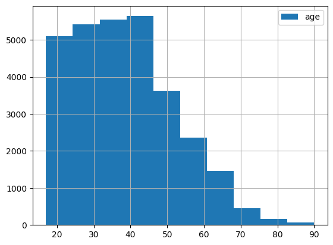

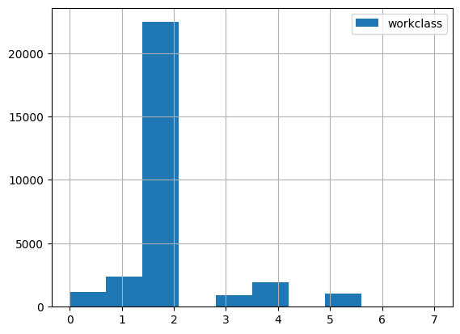

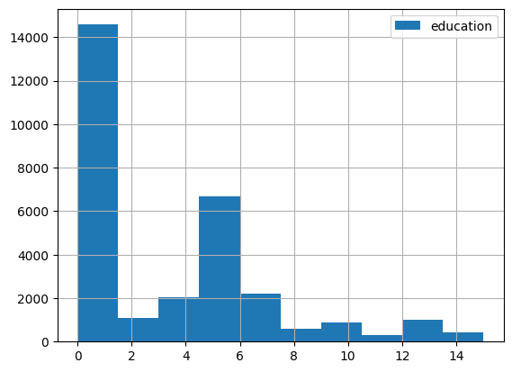

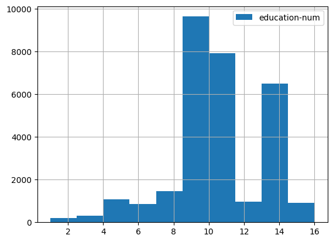

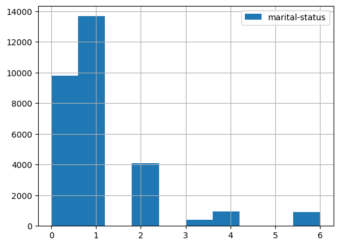

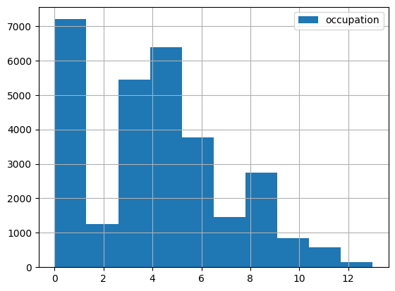

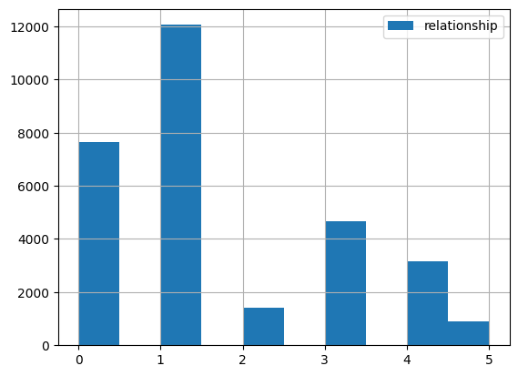

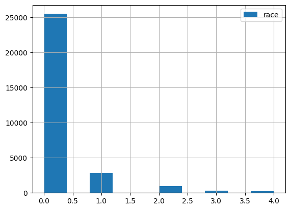

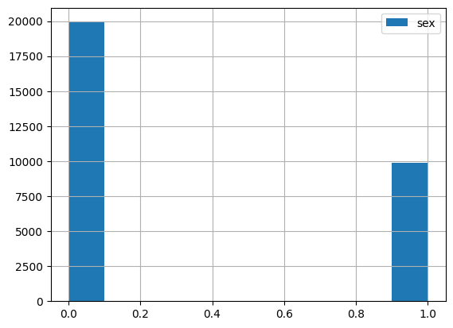

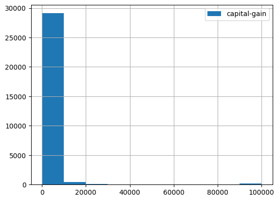

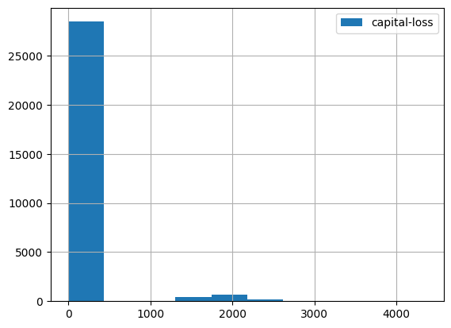

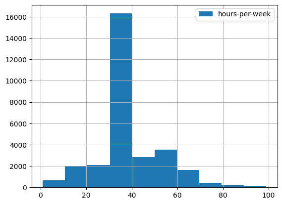

[2 more figures not shown]

```python
for i in range(0, 15) :
    if(i!=2) : # because'fnlwgt' is deleted
        plt.figure()
        trainDataFrame[getColumnNameByIndex(i)].hist(legend=True)
        plt.show()
```

## Part 10

### Data normalization

We use `std` method to find standard deviation of a list and `mean` to find average of a list.  
Then we normalize data for all numerical columns in dataframe

```python
trainDataFrame['age'] = ((trainDataFrame['age']-(trainDataFrame['age'].mean())) / (trainDataFrame['age'].std()))
trainDataFrame['education-num'] = ((trainDataFrame['education-num']-(trainDataFrame['education-num'].mean())) / (trainDataFrame['education-num'].std()))
trainDataFrame['capital-gain'] = ((trainDataFrame['capital-gain']-(trainDataFrame['capital-gain'].mean())) / (trainDataFrame['capital-gain'].std()))
trainDataFrame['capital-loss'] = ((trainDataFrame['capital-loss']-(trainDataFrame['capital-loss'].mean())) / (trainDataFrame['capital-loss'].std()))
trainDataFrame['hours-per-week'] = ((trainDataFrame['hours-per-week']-(trainDataFrame['hours-per-week'].mean())) / (trainDataFrame['hours-per-week'].std()))
trainDataFrame['sex'] = ((trainDataFrame['sex']-(trainDataFrame['sex'].mean())) / (trainDataFrame['sex'].std()))

trainDataFrame.head()
```

|  | age | workclass | education | education-num | marital-status | occupation | relationship | race | sex | capital-gain | capital-loss | hours-per-week | native-country | salary |
| --- | --- | --- | --- | --- | --- | --- | --- | --- | --- | --- | --- | --- | --- | --- |
| 0 | 0.030660 | 0.0 | 0 | 1.135745 | 0 | 0.0 | 0 | 0 | -0.703222 | 0.144193 | -0.215547 | -0.035288 | 0.0 | <=50K |
| 1 | 0.836403 | 1.0 | 0 | 1.135745 | 1 | 1.0 | 1 | 0 | -0.703222 | -0.146220 | -0.215547 | -2.228952 | 0.0 | <=50K |
| 2 | -0.042589 | 2.0 | 1 | -0.419659 | 2 | 2.0 | 0 | 0 | -0.703222 | -0.146220 | -0.215547 | -0.035288 | 0.0 | <=50K |
| 3 | 1.056151 | 2.0 | 2 | -1.197362 | 1 | 2.0 | 1 | 1 | -0.703222 | -0.146220 | -0.215547 | -0.035288 | 0.0 | <=50K |
| 4 | -0.775082 | 2.0 | 0 | 1.135745 | 1 | 3.0 | 2 | 1 | 1.421978 | -0.146220 | -0.215547 | -0.035288 | 1.0 | <=50K |

## PART 11

### PDF Plot

In this part we use `pdf()` method from `norm` field in scipy stats to create PDF of normal distribution of a column and plot it using scatter plot.  
We also use `std` and `mean` to find standard deviation and average of column in order to pass it to `pdf`  
We also get names of dataframe columns with numerical data by using `select_dtypes`  
(Column `sex` is also included)

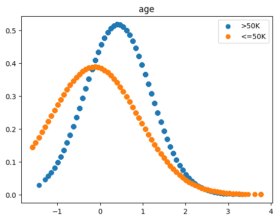

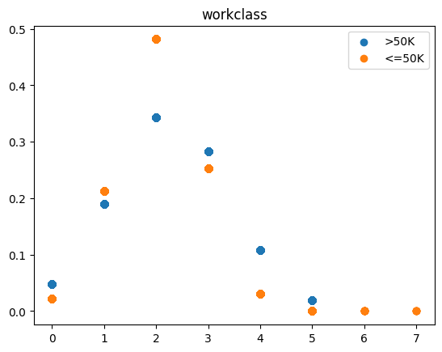

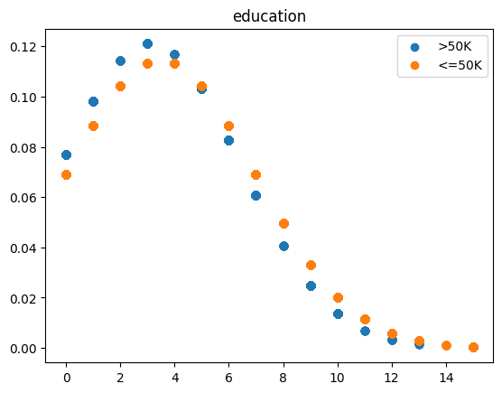

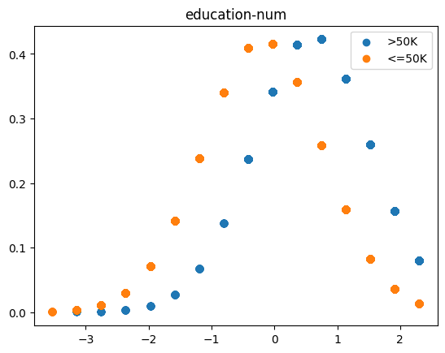

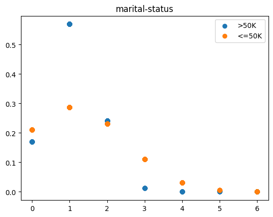

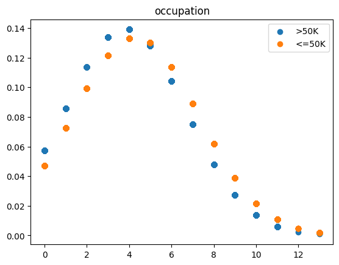

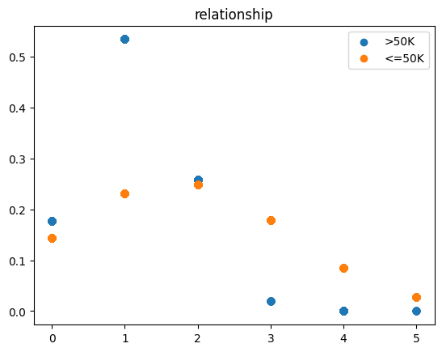

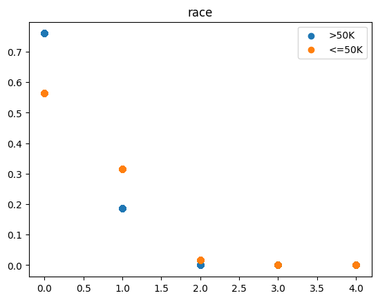

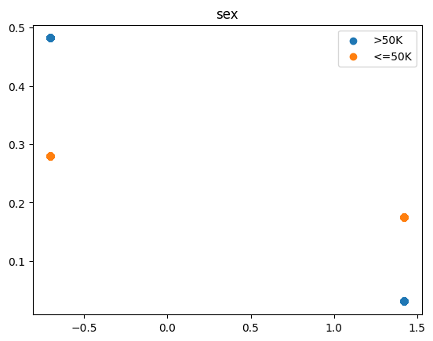

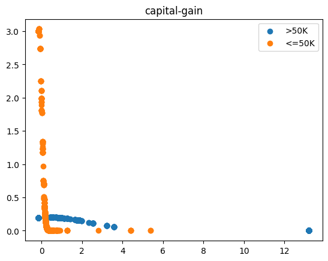

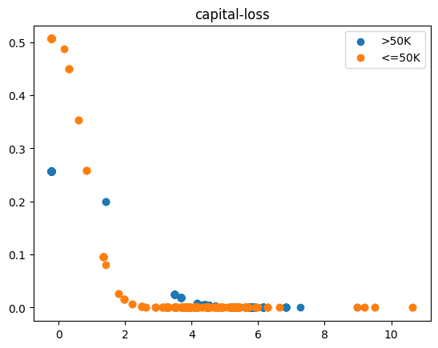

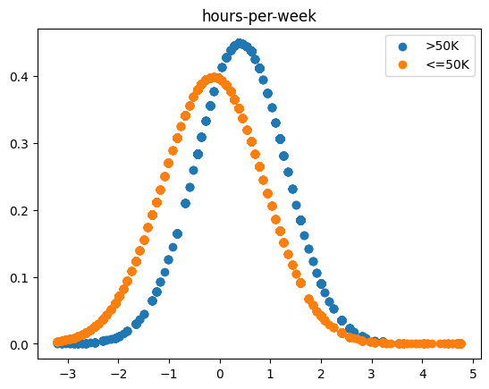

[1 more figures not shown]

```python
numericalDataColumns = list((trainDataFrame.select_dtypes(include=numpy.number)).columns)

for colName in numericalDataColumns :
    salaryHIGH50K = trainDataFrame.loc[(trainDataFrame['salary']=='>50K'), colName]
    salaryLOW50K = trainDataFrame.loc[(trainDataFrame['salary']=='<=50K'), colName]
    plt.title(colName)
    plt.scatter(salaryHIGH50K, scp.norm.pdf(salaryHIGH50K, salaryHIGH50K.mean(), salaryHIGH50K.std()), label='>50K')
    plt.scatter(salaryLOW50K, scp.norm.pdf(salaryLOW50K, salaryLOW50K.mean(), salaryLOW50K.std()), label='<=50K')
    plt.legend(['>50K', '<=50K'])
    plt.show()
```

The generated plots for `race` , `relationship` , `occupation` , `marital-status` , `education` , `workclass` can be ignored since they are encoded and not normalized.

## Part 12

### Reading test data

In this part we use `read_csv()` method like before to read `test.csv` into a dataframe.  
The `head()` method also makes use sure that data has been successfully read. We also must normalize data like before in order to make prediction.

```python
testDataFrame = pd.read_csv('test.csv')
testDataFrame = testDataFrame.replace(['Male', 'Female'] , [0, 1])
testDataFrame['age'] = ((testDataFrame['age']-(testDataFrame['age'].mean())) / (testDataFrame['age'].std()))
testDataFrame['education-num'] = ((testDataFrame['education-num']-(testDataFrame['education-num'].mean())) / (testDataFrame['education-num'].std()))
testDataFrame['capital-gain'] = ((testDataFrame['capital-gain']-(testDataFrame['capital-gain'].mean())) / (testDataFrame['capital-gain'].std()))
testDataFrame['capital-loss'] = ((testDataFrame['capital-loss']-(testDataFrame['capital-loss'].mean())) / (testDataFrame['capital-loss'].std()))
testDataFrame['hours-per-week'] = ((testDataFrame['hours-per-week']-(testDataFrame['hours-per-week'].mean())) / (testDataFrame['hours-per-week'].std()))
testDataFrame['sex'] = ((testDataFrame['sex']-(testDataFrame['sex'].mean())) / (testDataFrame['sex'].std()))

testDataFrame.head(2)
```

|  | age | workclass | fnlwgt | education | education-num | marital-status | occupation | relationship | race | sex | capital-gain | capital-loss | hours-per-week | native-country | salary |
| --- | --- | --- | --- | --- | --- | --- | --- | --- | --- | --- | --- | --- | --- | --- | --- |
| 0 | -1.005027 | Private | 230292 | HS-grad | -0.42426 | Married-civ-spouse | Craft-repair | Husband | White | -0.701171 | -0.14447 | -0.228418 | -0.036922 | United-States | <=50K |
| 1 | -0.191184 | Private | 90159 | Bachelors | 1.12344 | Married-civ-spouse | Prof-specialty | Wife | White | 1.425663 | -0.14447 | -0.228418 | -0.663401 | United-States | >50K |

### Prediction

In this part we use some of plots created at part 11 to make a prediction of a person salary

The plots of following dataframe columns are used to predict salary :

1. `sex`

If we take a look at this plot created at part 11 we can see that if `sex` value is more than 1 that person probably has a salary less than 50k `<=50K`  
but else it would probably have a salary more than 50K `>50K`  
however this prediction might not be completely accurate.  
Therefore we create a function named `getIncomePredictionResult_SEX` to make prediction based on `sex` value.

```python
def getIncomePredictionResult_SEX(sex_val) :
    if(sex_val < 1) :
        return '>50K'
    else :
        return '<=50K'
```

2. `capital-gain`

By taking a look at plot distribution (created at part 11) we can see that if `capital-gain` value is between 0.5 and 3.5 that person probably has a salary more than 50k `>50K`  
but else it would probably have a salary less than 50K `<=50K`  
The plot distribution is generally good for estimaton (prediction) but like before its not completely accurate.  
Now we create a function named `getIncomePredictionResult_GAIN` to make prediction based on `capital-gain` value.

```python
def getIncomePredictionResult_GAIN(capitalGain_val) :
    if((capitalGain_val < 3.5) and (capitalGain_val > 0.5)) :
        return '>50K'
    return '<=50K'
```

3. `hours-per-week`

The plot distribution tells us that if `hours-per-week` value is between 0.4 and 2.4 that person probably has a salary more than 50k `>50K`  
but else it would probably have a salary less than 50K `<=50K`  
This plot can also be a good estimator.  
Now we create a function named `getIncomePredictionResult_HPW` to make prediction based on `hours-per-week` value.

```python
def getIncomePredictionResult_HPW(hoursPerWeek_Val) :
    if((hoursPerWeek_Val > 0.4) and (hoursPerWeek_Val < 2.4)) :
        return '>50K'
    return '<=50K'
```

4. `age`

The `age` plot distribution also shows that it can be a good estimator.  
As we see if `age` value is between 0 and 2 that person probably has a salary more than 50k `>50K`  
but else it would probably have a salary less than 50K `<=50K`  
So we create a function named `getIncomePredictionResult_AGE` to make a prediction based on `age` value.

```python
def getIncomePredictionResult_AGE(age_val) :
    if((age_val > 0) and (age < 2)) :
        return '>50K'
    return '<=50K'
```

5. `education-num`

The `education-num` can also be a good estimator based on its plot.  
If `age` value is between 0.5 and 2.3 that person probably has a salary more than 50k `>50K`  
but else it would probably have a salary less than 50K `<=50K`  
So we create a function named `getIncomePredictionResult_EDNUM` to make a prediction based on `age` value.

```python
def getIncomePredictionResult_EDNUM(educationNum_val) :
    if((educationNum_val > 0.5) and (educationNum_val < 2.3)) :
        return '>50K'
    return '<=50K'
```

```python
testDataFrame['incomePrediction_sex'] = testDataFrame['sex'].map(getIncomePredictionResult_SEX)
testDataFrame['incomePrediction_GAIN'] = testDataFrame['capital-gain'].map(getIncomePredictionResult_GAIN)
testDataFrame['incomePrediction_HPW'] = testDataFrame['hours-per-week'].map(getIncomePredictionResult_HPW)
testDataFrame['incomePrediction_EDNUM'] = testDataFrame['education-num'].map(getIncomePredictionResult_EDNUM)
testDataFrame['incomePrediction_AGE'] = testDataFrame['age'].map(getIncomePredictionResult_EDNUM)

testDataFrame.head(20)
```

|  | age | workclass | fnlwgt | education | education-num | marital-status | occupation | relationship | race | sex | capital-gain | capital-loss | hours-per-week | native-country | salary | incomePrediction_sex | incomePrediction_GAIN | incomePrediction_HPW | incomePrediction_EDNUM | incomePrediction_AGE |
| --- | --- | --- | --- | --- | --- | --- | --- | --- | --- | --- | --- | --- | --- | --- | --- | --- | --- | --- | --- | --- |
| 0 | -1.005027 | Private | 230292 | HS-grad | -0.424260 | Married-civ-spouse | Craft-repair | Husband | White | -0.701171 | -0.144470 | -0.228418 | -0.036922 | United-States | <=50K | >50K | <=50K | <=50K | <=50K | <=50K |
| 1 | -0.191184 | Private | 90159 | Bachelors | 1.123440 | Married-civ-spouse | Prof-specialty | Wife | White | 1.425663 | -0.144470 | -0.228418 | -0.663401 | United-States | >50K | <=50K | <=50K | <=50K | >50K | <=50K |
| 2 | 0.104759 | Private | 175398 | Assoc-voc | 0.349590 | Divorced | Prof-specialty | Not-in-family | White | 1.425663 | -0.144470 | -0.228418 | -1.603119 | United-States | <=50K | <=50K | <=50K | <=50K | <=50K | <=50K |
| 3 | 1.288531 | Self-emp-not-inc | 53366 | 11th | -1.198110 | Married-civ-spouse | Craft-repair | Husband | White | -0.701171 | -0.144470 | -0.228418 | -1.603119 | United-States | <=50K | >50K | <=50K | <=50K | <=50K | >50K |
| 4 | 0.844616 | Private | 46155 | Assoc-voc | 0.349590 | Divorced | Prof-specialty | Unmarried | White | 1.425663 | -0.144470 | -0.228418 | -0.036922 | United-States | >50K | <=50K | <=50K | <=50K | <=50K | >50K |
| 5 | 1.214545 | Private | 61708 | HS-grad | -0.424260 | Married-civ-spouse | Adm-clerical | Husband | White | -0.701171 | 0.893818 | -0.228418 | 0.746176 | United-States | >50K | >50K | >50K | >50K | <=50K | >50K |
| 6 | -0.487127 | Local-gov | 112650 | HS-grad | -0.424260 | Married-civ-spouse | Protective-serv | Husband | White | -0.701171 | -0.144470 | -0.228418 | -0.036922 | United-States | <=50K | >50K | <=50K | <=50K | <=50K | <=50K |
| 7 | 0.178745 | Private | 173682 | Assoc-voc | 0.349590 | Married-civ-spouse | Craft-repair | Husband | White | -0.701171 | -0.144470 | -0.228418 | 0.198007 | United-States | >50K | >50K | <=50K | <=50K | <=50K | <=50K |
| 8 | -0.783070 | Private | 160981 | Some-college | -0.037335 | Never-married | Adm-clerical | Not-in-family | White | 1.425663 | -0.144470 | -0.228418 | 0.902795 | United-States | <=50K | <=50K | <=50K | >50K | <=50K | <=50K |
| 9 | 1.066574 | Private | 72257 | Some-college | -0.037335 | Married-civ-spouse | Exec-managerial | Husband | White | -0.701171 | -0.144470 | -0.228418 | 1.137725 | United-States | <=50K | >50K | <=50K | >50K | <=50K | >50K |
| 10 | -0.931041 | NaN | 182332 | Assoc-voc | 0.349590 | Married-civ-spouse | NaN | Wife | White | 1.425663 | -0.144470 | -0.228418 | -0.036922 | United-States | <=50K | <=50K | <=50K | <=50K | <=50K | <=50K |
| 11 | 1.584474 | Local-gov | 48788 | Bachelors | 1.123440 | Separated | Prof-specialty | Unmarried | White | 1.425663 | 0.738026 | -0.228418 | 1.137725 | United-States | <=50K | <=50K | >50K | >50K | >50K | >50K |
| 12 | -1.300970 | Private | 417668 | Some-college | -0.037335 | Never-married | Other-service | Own-child | White | -0.701171 | -0.144470 | -0.228418 | -1.603119 | United-States | <=50K | >50K | <=50K | <=50K | <=50K | <=50K |
| 13 | -0.709084 | Private | 107458 | HS-grad | -0.424260 | Married-civ-spouse | Transport-moving | Husband | White | -0.701171 | -0.144470 | -0.228418 | -0.036922 | United-States | <=50K | >50K | <=50K | <=50K | <=50K | <=50K |
| 14 | 2.546289 | Private | 147551 | Some-college | -0.037335 | Married-civ-spouse | Prof-specialty | Husband | White | -0.701171 | -0.144470 | 4.926978 | 0.746176 | United-States | >50K | >50K | <=50K | >50K | <=50K | <=50K |
| 15 | 0.326716 | Self-emp-inc | 33729 | Bachelors | 1.123440 | Married-civ-spouse | Sales | Husband | White | -0.701171 | -0.144470 | -0.228418 | 0.354627 | United-States | >50K | >50K | <=50K | <=50K | >50K | <=50K |
| 16 | 0.474688 | Private | 101977 | Some-college | -0.037335 | Married-civ-spouse | Sales | Husband | White | -0.701171 | -0.144470 | -0.228418 | 0.354627 | United-States | <=50K | >50K | <=50K | <=50K | <=50K | <=50K |
| 17 | -0.265170 | NaN | 374716 | 9th | -1.971960 | Married-civ-spouse | NaN | Wife | White | 1.425663 | -0.144470 | -0.228418 | -0.428471 | United-States | <=50K | <=50K | <=50K | <=50K | <=50K | <=50K |
| 18 | -0.191184 | Private | 214378 | HS-grad | -0.424260 | Divorced | Prof-specialty | Own-child | White | 1.425663 | -0.144470 | -0.228418 | -0.036922 | United-States | >50K | <=50K | <=50K | <=50K | <=50K | <=50K |
| 19 | -1.005027 | Private | 111243 | HS-grad | -0.424260 | Never-married | Sales | Other-relative | White | 1.425663 | -0.144470 | -0.228418 | 0.746176 | United-States | <=50K | <=50K | <=50K | >50K | <=50K | <=50K |

### Writing dataframe to csv file

We use `to_csv` method to write a dataframe to csv file.  
We also give `columns` argument as following to indicate specific columns to be written on file.  
Also if we want to remove indexes from created csv file we set `index` argument to `index=False`.

```python
testDataFrame.to_csv('salaryPrediction.csv', columns =
['salary', 'incomePrediction_sex', 'incomePrediction_GAIN', 'incomePrediction_HPW', 'incomePrediction_EDNUM', 'incomePrediction_AGE'],
index = True)
```

Output file gets created with prediction data inside it.